## Бусько Полина, гр. 3824М1ПМвм

# Лабораторная работа 3: Перенос знаний с использованием PyTorch

### Цели работы

Цель данной работы — изучить и реализовать метод переноса знаний (transfer learning) для глубоких нейронных сетех для решения задачи классификации отходов на основе набора данных Garbage Classification. Предлагается применение переноса знаний к известным моделям глубокого обучения, обученным на наборе данных ImageNet.

### Задачи работы

Выполнение лабораторной работы предполагает решение следующих задач:

1. Загрузить набор данных Garbage Classification и выполнить предобработку данных, если это необходимо.
2. Выбрать 4 архитектуры нейронных сетей, для которых в открытом доступе существуют веса, настроенные на наборе данных ImageNet.
3. Модифицировать выбранные архитектуры нейронных сетей для работы с набором данных Garbage Classification. Выбрать гиперпараметры обучения и функцию ошибки.
4. Обучить модели со случайными весами на наборе данных Garbage Classification.
5. Обучить модель с весами, предварительно обученными на наборе данных ImageNet, на том же наборе данных Garbage Classification.
6. Сравнить результаты обученных моделей по метрикам точности.

### Требования к результатам выполнения работы

1. Структура и содержимое Jupyter Notebook:
- Необходимо обеспечить демонстрацию избранных изображений и меток классов для подтверждения корректности загрузки и совпадения размерностей.
- Загрузить и обучить 4 нейронные сети (можно использовать torchvision). Для каждой модели провести 2 эксперимента: первый — обучить модель со случайными весами, второй — реализовать перенос знаний, используя веса, обученные на ImageNet (выбрать любую модель, которая подходит для переноса знаний).
- Построить график Macro F1-score от количества эпох для всех моделей на валидационных данных. Построить сравнительную столбчатую диаграмму точностей: модель и тип эксперимента (с кратким указанием параметров) по горизонтали, Macro F1-score на тестовых данных по вертикали.
1. Проверка корректности:
- Разделите датасет на тренировочную, валидационную и тестовую выборки самостоятельно в соотношении 70/15/15.
- Для оценки качества следует использовать Macro F1-score, поскольку датасет не сбалансирован.
1. Архитектуры:
- Можно использовать любые сверточные архитектуры или архитектуры на базе механизма внимания (transformer, ViT и т.д.).
- Хорошее понимание работы выбранных архитектур напрямую влияет на количество баллов за "знание". Будьте готовы кратко рассказать о особенностях выбранных или одной из выбранных архитектур при очной сдаче лабораторной работы.
- Не бойтесь выбирать сложные архитектуры — чем сложнее архитектура, тем больше в ней интересного.

```python
import torch
import torchvision
from torchvision import models
from torchvision import datasets
import torchvision.transforms as transforms
import torch.nn as nn
import torch.optim as optim
from torch.utils.data import DataLoader, random_split
import matplotlib.pyplot as plt
import numpy as np
from sklearn.metrics import f1_score
from torch.utils.data import Subset
import time
```

#### Гиперпараметры

```python
learning_rate = 0.001
epochs = 20
batch_size = 32
```

#### Загрузка и проверка корректности данных

```python
import kagglehub

# Download latest version
path = kagglehub.dataset_download("asdasdasasdas/garbage-classification")

print("Path to dataset files:", path)
```

```
Downloading from https://www.kaggle.com/api/v1/datasets/download/asdasdasasdas/garbage-classification?dataset_version_number=2...
```

```
Extracting files...
```

```
Path to dataset files: /root/.cache/kagglehub/datasets/asdasdasasdas/garbage-classification/versions/2
```

```python
transform = transforms.Compose([transforms.Resize((224, 224)),
                                transforms.ToTensor(),
                                transforms.Normalize((0.5, 0.5, 0.5), (0.5, 0.5, 0.5))])

dataset = datasets.ImageFolder(root = f"{path}/Garbage classification/Garbage classification", transform = transform)
train_dataset, validation_dataset, test_dataset = torch.utils.data.random_split(dataset, [0.7, 0.15, 0.15])

train_loader = torch.utils.data.DataLoader(train_dataset, batch_size = batch_size, shuffle = True)
validation_loader = torch.utils.data.DataLoader(validation_dataset, batch_size = batch_size, shuffle = True)
test_loader = torch.utils.data.DataLoader(test_dataset, batch_size = batch_size, shuffle = False)
```

```python
print(f"Классы: {dataset.classes}")
print(f"Общий размер выборки: {len(dataset)}")
print(f"Размер тренеровочной выборки: {len(train_dataset)}")
print(f"Размер валидационной выборки: {len(validation_dataset)}")
print(f"Размер тестовой выборки: {len(test_dataset)}")
```

```
Классы: ['cardboard', 'glass', 'metal', 'paper', 'plastic', 'trash']
Общий размер выборки: 2527
Размер тренеровочной выборки: 1769
Размер валидационной выборки: 379
Размер тестовой выборки: 379
```

```python
def plot_garbage(loader, s, size = 5):
    fig, axs = plt.subplots(size, size, figsize=(10,10))
    indexes = np.random.randint(low=0, high=len(loader.dataset), size=size*size)
    fig.suptitle(s)
    for i in range(size):
        for j in range(size):
            idx = indexes[i * size + j]

            image, label = loader.dataset[idx]
            image = image.permute(1, 2, 0)
            image = image * torch.tensor([0.5, 0.5, 0.5]) + torch.tensor([0.5, 0.5, 0.5])
            image = image.clip(0, 1)

            axs[i, j].imshow(image)
            axs[i, j].axis('off')
            axs[i, j].set_title(f"{loader.dataset.dataset.classes[label]}")
    plt.tight_layout()
    plt.show()
```

[figure not shown]

```python
plot_garbage(train_loader, "Примеры тренировочных данных")
```

[figure not shown]

```python
plot_garbage(validation_loader, "Примеры валидационных данных")
```

[figure not shown]

```python
plot_garbage(test_loader,"Примеры тестовых данных")
```

### Эксперименты

```python
device = torch.device("cuda" if torch.cuda.is_available() else "cpu")
print(f'Device: {device}')
```

```
Device: cuda
```

```python
num_classes = len(dataset.classes)
loss_function = nn.CrossEntropyLoss().to(device)

def train(model, optimizer, train_loader):
    model.train()
    loss_list = []
    accuracy_list = []

    time_one = time.time()
    for images, labels in train_loader:
        images = images.to(device)
        labels = labels.to(device)

        outputs = model.forward(images)
        loss = loss_function(outputs, labels)

        optimizer.zero_grad()
        loss.backward()
        optimizer.step()

        loss_list.append(loss)
        accuracy_list.append(torch.mean(torch.argmax(outputs, dim = 1) == labels, dtype = float))

    diff_time = time.time() - time_one
    return loss_list, accuracy_list, diff_time

def validation(model, validation_loader):
    model.eval()
    f1_score_list = []
    loss_list = []
    accuracy_list = []

    time_one = time.time()
    with torch.no_grad():
        for images, labels in validation_loader:
            images = images.to(device)
            labels = labels.to(device)

            outputs = model.forward(images)
            loss = loss_function(outputs, labels)

            f1_score_list.append(torch.tensor(f1_score(torch.argmax(outputs, dim = 1).cpu(), labels.cpu(), average = 'macro')))
            loss_list.append(loss)
            accuracy_list.append(torch.mean(torch.argmax(outputs, dim = 1) == labels, dtype = float))

    diff_time = time.time() - time_one
    return f1_score_list, loss_list, accuracy_list, diff_time

def test(model, test_loader):
    f1_score_list = []

    with torch.no_grad():
        for images, labels in test_loader:
            images = images.to(device)
            labels = labels.to(device)

            outputs = model.forward(images)

            f1_score_list.append(torch.tensor(f1_score(torch.argmax(outputs, dim = 1).cpu(), labels.cpu(), average = 'macro')))
    return f1_score_list
```

```python
def experiment(model):
    f1_valid_for_graph = []
    optimizer = optim.Adam(model.parameters(), lr = learning_rate)

    for epoch in range(epochs):
        print(f"Epoch: {epoch + 1}/{epochs} ")
        train_loss, accuracy_train, time_train = train(model, optimizer, train_loader)

        print(f"train loss = {torch.stack(train_loss).mean():.3f}, "
              f"train accuracy = {torch.stack(accuracy_train).mean():.3f}, "
              f"train time = {time_train:.2f} "
        )

        f1_score_list, validation_loss, accuracy_validation, time_validation = validation(model, validation_loader)

        print(f"validation loss = {torch.stack(validation_loss).mean():.3f}, "
              f"validation accuracy = {torch.stack(accuracy_validation).mean():.3f}, "
              f"validation time = {time_validation:.2f}, "
              f"f1-score = {torch.stack(f1_score_list).mean():.3f} \n"
        )

        f1_valid_for_graph.append(torch.stack(f1_score_list).mean())

    f1_score_test = test(model, test_loader)
    print(f"Test f1-score:{torch.stack(f1_score_test).mean():.3f} ")
    return f1_valid_for_graph, torch.stack(f1_score_test).mean()
```

```python
def plot_f1_score(f1, epochs, name):
    plt.plot(range(epochs), f1, marker="o", color="darkblue")
    plt.title(f"{name}")
    plt.xlabel("Epoch")
    plt.xticks([i for i in range(epochs)])
    plt.ylabel("f1-score")
    plt.grid()
    plt.show()
```

#### Рассматриваемые архитектуры:

1. VGG-16
2. GoogLeNet
3. ResNet-34
4. ResNet-50

#### VGG-16

```python
def vgg16_random_weights(num_classes):
    # Инициализируем модель со случайными весами
    model = models.vgg16(weights=None)  # Не исполбзуются предобученные веса
    for param in model.parameters():
        param.requires_grad = True  # Все параметры обучаются
    model.classifier[6] = nn.Linear(model.classifier[6].in_features, num_classes)
    return model


def vgg16_transfer(num_classes):
    model = models.vgg16(weights=models.VGG16_Weights.DEFAULT)

    # Замораживаем features (сверточные слои), общие признаки
    for param in model.features.parameters():
        param.requires_grad = False

    model.avgpool = nn.Sequential(
        nn.Conv2d(512, 256, kernel_size=3, padding=1),
        nn.BatchNorm2d(256),
        nn.ReLU(),
        nn.Conv2d(256, 128, kernel_size=3, padding=1),
        nn.BatchNorm2d(128),
        nn.ReLU(),
        nn.AdaptiveAvgPool2d((5, 5))
    )

    model.classifier = nn.Sequential(nn.Linear(128 * 5 * 5, 1024),
                                     nn.ReLU(),
                                     nn.Dropout(0.3),
                                     nn.Linear(1024, num_classes)
    )

    return model
```

Гиперпараметры обучения

```python
learning_rate = 0.001
epochs = 50
batch_size = 32
```

```python
train_loader = torch.utils.data.DataLoader(train_dataset, batch_size = batch_size, shuffle = True)
validation_loader = torch.utils.data.DataLoader(validation_dataset, batch_size = batch_size, shuffle = True)
test_loader = torch.utils.data.DataLoader(test_dataset, batch_size = batch_size, shuffle = False)
```

```
Epoch: 1/50
train loss = 3.360, train accuracy = 0.222, train time = 25.22
validation loss = 1.728, validation accuracy = 0.222, validation time = 3.06, f1-score = 0.061

Epoch: 2/50
train loss = 1.730, train accuracy = 0.232, train time = 23.97
validation loss = 1.732, validation accuracy = 0.221, validation time = 3.45, f1-score = 0.060

Epoch: 3/50
train loss = 1.725, train accuracy = 0.233, train time = 24.39
validation loss = 1.730, validation accuracy = 0.223, validation time = 3.09, f1-score = 0.060

Epoch: 4/50
train loss = 1.723, train accuracy = 0.238, train time = 24.84
validation loss = 1.728, validation accuracy = 0.221, validation time = 3.10, f1-score = 0.061

Epoch: 5/50
train loss = 1.727, train accuracy = 0.235, train time = 24.65
validation loss = 1.727, validation accuracy = 0.221, validation time = 3.44, f1-score = 0.062

Epoch: 6/50
train loss = 1.725, train accuracy = 0.235, train time = 24.16
validation loss = 1.725, validation accuracy = 0.223, validation time = 3.07, f1-score = 0.064

Epoch: 7/50
train loss = 1.727, train accuracy = 0.234, train time = 24.27
validation loss = 1.728, validation accuracy = 0.220, validation time = 3.10, f1-score = 0.060

Epoch: 8/50
train loss = 1.724, train accuracy = 0.235, train time = 24.34
validation loss = 1.730, validation accuracy = 0.222, validation time = 3.19, f1-score = 0.062

Epoch: 9/50
train loss = 1.730, train accuracy = 0.236, train time = 24.34
validation loss = 1.727, validation accuracy = 0.221, validation time = 3.26, f1-score = 0.059

Epoch: 10/50
train loss = 1.727, train accuracy = 0.236, train time = 24.28
validation loss = 1.727, validation accuracy = 0.220, validation time = 3.06, f1-score = 0.061

```

[output cut: 146 more lines]

```
validation loss = 1.728, validation accuracy = 0.223, validation time = 3.06, f1-score = 0.062

Epoch: 48/50
train loss = 1.722, train accuracy = 0.236, train time = 24.31
validation loss = 1.728, validation accuracy = 0.221, validation time = 3.08, f1-score = 0.063

Epoch: 49/50
train loss = 1.722, train accuracy = 0.239, train time = 24.31
validation loss = 1.727, validation accuracy = 0.224, validation time = 3.15, f1-score = 0.063

Epoch: 50/50
train loss = 1.724, train accuracy = 0.238, train time = 24.36
validation loss = 1.727, validation accuracy = 0.221, validation time = 3.34, f1-score = 0.061

Test f1-score:0.067
```

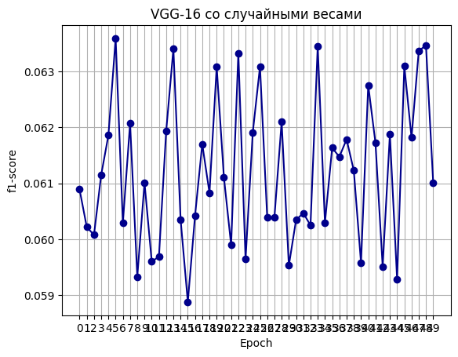

```python
vgg16_model_random = vgg16_random_weights(num_classes).to(device)

f1_validation_random, f1_test_vgg16_random = experiment(vgg16_model_random)
plot_f1_score(f1_validation_random, epochs, "VGG-16 со случайными весами")
```

```
Downloading: "https://download.pytorch.org/models/vgg16-397923af.pth" to /root/.cache/torch/hub/checkpoints/vgg16-397923af.pth
```

```
Epoch: 1/15
train loss = 0.953, train accuracy = 0.650, train time = 8.65
validation loss = 0.734, validation accuracy = 0.735, validation time = 3.28, f1-score = 0.671

Epoch: 2/15
train loss = 0.433, train accuracy = 0.839, train time = 8.62
validation loss = 0.549, validation accuracy = 0.817, validation time = 3.31, f1-score = 0.794

Epoch: 3/15
train loss = 0.260, train accuracy = 0.900, train time = 8.89
validation loss = 0.591, validation accuracy = 0.808, validation time = 3.32, f1-score = 0.787

Epoch: 4/15
train loss = 0.181, train accuracy = 0.935, train time = 8.72
validation loss = 0.563, validation accuracy = 0.826, validation time = 3.25, f1-score = 0.804

Epoch: 5/15
train loss = 0.145, train accuracy = 0.945, train time = 8.55
validation loss = 0.592, validation accuracy = 0.820, validation time = 3.28, f1-score = 0.791

Epoch: 6/15
train loss = 0.070, train accuracy = 0.979, train time = 8.44
validation loss = 0.895, validation accuracy = 0.797, validation time = 3.37, f1-score = 0.766

Epoch: 7/15
train loss = 0.089, train accuracy = 0.968, train time = 8.38
validation loss = 0.804, validation accuracy = 0.811, validation time = 3.44, f1-score = 0.768

Epoch: 8/15
train loss = 0.093, train accuracy = 0.970, train time = 8.40
validation loss = 0.934, validation accuracy = 0.782, validation time = 3.49, f1-score = 0.747

Epoch: 9/15
train loss = 0.107, train accuracy = 0.964, train time = 8.45
validation loss = 0.858, validation accuracy = 0.810, validation time = 3.56, f1-score = 0.778

Epoch: 10/15
train loss = 0.073, train accuracy = 0.980, train time = 8.51
validation loss = 0.738, validation accuracy = 0.810, validation time = 3.46, f1-score = 0.783

Epoch: 11/15
train loss = 0.062, train accuracy = 0.977, train time = 8.50
validation loss = 0.796, validation accuracy = 0.805, validation time = 3.43, f1-score = 0.794

Epoch: 12/15
train loss = 0.080, train accuracy = 0.975, train time = 8.51
validation loss = 0.803, validation accuracy = 0.820, validation time = 3.48, f1-score = 0.785

Epoch: 13/15
train loss = 0.061, train accuracy = 0.979, train time = 8.49
validation loss = 0.664, validation accuracy = 0.824, validation time = 3.45, f1-score = 0.791

Epoch: 14/15
train loss = 0.028, train accuracy = 0.990, train time = 8.48
validation loss = 0.773, validation accuracy = 0.829, validation time = 3.48, f1-score = 0.801

Epoch: 15/15
train loss = 0.017, train accuracy = 0.994, train time = 8.47
validation loss = 0.760, validation accuracy = 0.829, validation time = 3.49, f1-score = 0.804

Test f1-score:0.802
```

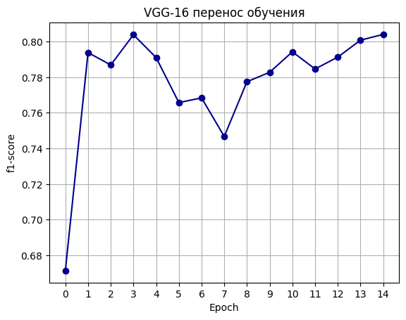

```python
learning_rate = 0.0005
epochs = 15

vgg16_model_transfer = vgg16_transfer(num_classes).to(device)

f1_validation_vgg16_transfer, f1_test_vgg16_transfer = experiment(vgg16_model_transfer)
plot_f1_score(f1_validation_vgg16_transfer, epochs, "VGG-16 перенос обучения")
```

#### GoogLeNet

```python
def googlenet_random_weights(num_classes):
    model = models.googlenet(weights=None, init_weights=True, aux_logits=False)  # ← aux_logits=False
    for param in model.parameters():
        param.requires_grad = True  # Все параметры обучаются

    # Заменяем последний слой
    model.fc = nn.Linear(model.fc.in_features, num_classes)
    return model

def googlenet_transfer(num_classes):
    model = models.googlenet(weights=models.GoogLeNet_Weights.DEFAULT)

    for param in model.parameters():
        param.requires_grad = False

    model.fc = nn.Sequential(nn.Linear(1024, 512),
                             nn.ReLU(),
                             nn.Linear(512, num_classes)
    )

    return model
```

Гиперпараметры обучения

```python
learning_rate = 0.001
epochs = 20
batch_size = 32
```

```python
train_loader = torch.utils.data.DataLoader(train_dataset, batch_size = batch_size, shuffle = True)
validation_loader = torch.utils.data.DataLoader(validation_dataset, batch_size = batch_size, shuffle = True)
test_loader = torch.utils.data.DataLoader(test_dataset, batch_size = batch_size, shuffle = False)
```

```
Epoch: 1/20
train loss = 1.511, train accuracy = 0.404, train time = 8.91
validation loss = 1.499, validation accuracy = 0.388, validation time = 1.71, f1-score = 0.328

Epoch: 2/20
train loss = 1.310, train accuracy = 0.498, train time = 8.14
validation loss = 10.719, validation accuracy = 0.278, validation time = 2.06, f1-score = 0.155

Epoch: 3/20
train loss = 1.210, train accuracy = 0.555, train time = 7.88
validation loss = 1.551, validation accuracy = 0.426, validation time = 1.90, f1-score = 0.327

Epoch: 4/20
train loss = 1.182, train accuracy = 0.567, train time = 8.32
validation loss = 2.115, validation accuracy = 0.405, validation time = 1.74, f1-score = 0.315

Epoch: 5/20
train loss = 1.159, train accuracy = 0.580, train time = 8.51
validation loss = 1.247, validation accuracy = 0.530, validation time = 1.70, f1-score = 0.464

Epoch: 6/20
train loss = 1.061, train accuracy = 0.615, train time = 8.47
validation loss = 1.428, validation accuracy = 0.574, validation time = 1.76, f1-score = 0.472

Epoch: 7/20
train loss = 1.094, train accuracy = 0.600, train time = 8.55
validation loss = 1.146, validation accuracy = 0.598, validation time = 1.75, f1-score = 0.503

Epoch: 8/20
train loss = 1.018, train accuracy = 0.629, train time = 8.31
validation loss = 1.181, validation accuracy = 0.587, validation time = 1.94, f1-score = 0.478

Epoch: 9/20
train loss = 0.982, train accuracy = 0.652, train time = 7.84
validation loss = 1.154, validation accuracy = 0.538, validation time = 2.02, f1-score = 0.490

Epoch: 10/20
train loss = 0.947, train accuracy = 0.670, train time = 8.11
validation loss = 1.371, validation accuracy = 0.500, validation time = 1.69, f1-score = 0.422

```

[output cut: 26 more lines]

```
validation loss = 1.093, validation accuracy = 0.630, validation time = 1.69, f1-score = 0.530

Epoch: 18/20
train loss = 0.732, train accuracy = 0.741, train time = 8.50
validation loss = 1.001, validation accuracy = 0.676, validation time = 1.70, f1-score = 0.619

Epoch: 19/20
train loss = 0.766, train accuracy = 0.725, train time = 8.53
validation loss = 0.891, validation accuracy = 0.697, validation time = 1.71, f1-score = 0.630

Epoch: 20/20
train loss = 0.672, train accuracy = 0.761, train time = 8.37
validation loss = 0.943, validation accuracy = 0.670, validation time = 1.88, f1-score = 0.646

Test f1-score:0.600
```

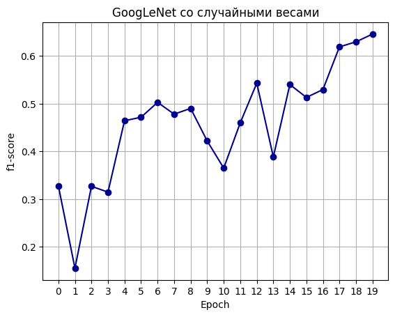

```python
googlenet_model_random = googlenet_random_weights(num_classes).to(device)

f1_validation_googlenet_random, f1_test_googlenet_random = experiment(googlenet_model_random)
plot_f1_score(f1_validation_googlenet_random, epochs, "GoogLeNet со случайными весами")
```

```
Downloading: "https://download.pytorch.org/models/googlenet-1378be20.pth" to /root/.cache/torch/hub/checkpoints/googlenet-1378be20.pth
```

```
Epoch: 1/20
train loss = 1.110, train accuracy = 0.578, train time = 7.41
validation loss = 0.660, validation accuracy = 0.766, validation time = 2.25, f1-score = 0.704

Epoch: 2/20
train loss = 0.683, train accuracy = 0.753, train time = 6.92
validation loss = 0.614, validation accuracy = 0.778, validation time = 1.78, f1-score = 0.737

Epoch: 3/20
train loss = 0.595, train accuracy = 0.785, train time = 7.56
validation loss = 0.535, validation accuracy = 0.805, validation time = 1.79, f1-score = 0.775

Epoch: 4/20
train loss = 0.548, train accuracy = 0.806, train time = 7.53
validation loss = 0.647, validation accuracy = 0.748, validation time = 1.80, f1-score = 0.705

Epoch: 5/20
train loss = 0.501, train accuracy = 0.833, train time = 7.49
validation loss = 0.506, validation accuracy = 0.840, validation time = 1.97, f1-score = 0.798

Epoch: 6/20
train loss = 0.458, train accuracy = 0.832, train time = 6.95
validation loss = 0.541, validation accuracy = 0.791, validation time = 1.87, f1-score = 0.716

Epoch: 7/20
train loss = 0.422, train accuracy = 0.850, train time = 7.25
validation loss = 0.579, validation accuracy = 0.783, validation time = 1.72, f1-score = 0.747

Epoch: 8/20
train loss = 0.427, train accuracy = 0.843, train time = 7.52
validation loss = 0.478, validation accuracy = 0.836, validation time = 1.76, f1-score = 0.817

Epoch: 9/20
train loss = 0.410, train accuracy = 0.847, train time = 7.50
validation loss = 0.460, validation accuracy = 0.856, validation time = 1.88, f1-score = 0.794

Epoch: 10/20
train loss = 0.350, train accuracy = 0.877, train time = 6.67
validation loss = 0.463, validation accuracy = 0.839, validation time = 1.85, f1-score = 0.819

```

[output cut: 26 more lines]

```
validation loss = 0.457, validation accuracy = 0.849, validation time = 1.85, f1-score = 0.814

Epoch: 18/20
train loss = 0.257, train accuracy = 0.906, train time = 6.91
validation loss = 0.641, validation accuracy = 0.800, validation time = 2.02, f1-score = 0.785

Epoch: 19/20
train loss = 0.250, train accuracy = 0.914, train time = 7.34
validation loss = 0.457, validation accuracy = 0.842, validation time = 1.81, f1-score = 0.838

Epoch: 20/20
train loss = 0.245, train accuracy = 0.908, train time = 7.40
validation loss = 0.438, validation accuracy = 0.865, validation time = 1.82, f1-score = 0.846

Test f1-score:0.780
```

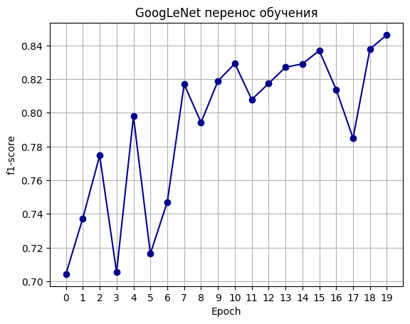

```python
googlenet_model_transfer = googlenet_transfer(num_classes).to(device)

f1_validation_googlenet_transfer, f1_test_googlenet_transfer = experiment(googlenet_model_transfer)
plot_f1_score(f1_validation_googlenet_transfer, epochs, "GoogLeNet перенос обучения")
```

#### ResNet-34

```python
def resnet34_random_weights(num_classes):
    model = models.resnet34(weights=None)
    for param in model.parameters():
        param.requires_grad = True  # Все параметры обучаются

    # Заменяем последний полносвязный слой
    model.fc = nn.Linear(model.fc.in_features, num_classes)
    return model

def resnet34_transfer(num_classes):
    model = models.resnet34(weights=models.ResNet34_Weights.DEFAULT)
    for param in model.parameters():
        param.requires_grad = False

    model.fc = nn.Sequential(nn.Linear(512, 256),
                             nn.ReLU(),
                             nn.Linear(256, num_classes)
    )

    return model
```

Гиперпараметры обучения

```python
learning_rate = 0.001
epochs = 25
batch_size = 32
```

```python
train_loader = torch.utils.data.DataLoader(train_dataset, batch_size = batch_size, shuffle = True)
validation_loader = torch.utils.data.DataLoader(validation_dataset, batch_size = batch_size, shuffle = True)
test_loader = torch.utils.data.DataLoader(test_dataset, batch_size = batch_size, shuffle = False)
```

```
Epoch: 1/25
train loss = 1.507, train accuracy = 0.432, train time = 9.46
validation loss = 1.469, validation accuracy = 0.436, validation time = 1.84, f1-score = 0.348

Epoch: 2/25
train loss = 1.316, train accuracy = 0.481, train time = 9.39
validation loss = 1.563, validation accuracy = 0.476, validation time = 1.84, f1-score = 0.406

Epoch: 3/25
train loss = 1.271, train accuracy = 0.516, train time = 9.27
validation loss = 1.651, validation accuracy = 0.397, validation time = 1.88, f1-score = 0.322

Epoch: 4/25
train loss = 1.224, train accuracy = 0.535, train time = 9.20
validation loss = 1.271, validation accuracy = 0.508, validation time = 1.85, f1-score = 0.428

Epoch: 5/25
train loss = 1.219, train accuracy = 0.548, train time = 9.15
validation loss = 2.468, validation accuracy = 0.330, validation time = 1.81, f1-score = 0.202

Epoch: 6/25
train loss = 1.131, train accuracy = 0.567, train time = 9.07
validation loss = 1.432, validation accuracy = 0.502, validation time = 1.91, f1-score = 0.437

Epoch: 7/25
train loss = 1.114, train accuracy = 0.583, train time = 8.90
validation loss = 1.208, validation accuracy = 0.548, validation time = 2.28, f1-score = 0.468

Epoch: 8/25
train loss = 1.059, train accuracy = 0.607, train time = 8.88
validation loss = 3.644, validation accuracy = 0.527, validation time = 2.49, f1-score = 0.413

Epoch: 9/25
train loss = 1.069, train accuracy = 0.618, train time = 8.95
validation loss = 1.283, validation accuracy = 0.557, validation time = 2.19, f1-score = 0.465

Epoch: 10/25
train loss = 0.972, train accuracy = 0.648, train time = 9.09
validation loss = 1.256, validation accuracy = 0.509, validation time = 1.90, f1-score = 0.422

```

[output cut: 46 more lines]

```
validation loss = 0.876, validation accuracy = 0.684, validation time = 2.04, f1-score = 0.622

Epoch: 23/25
train loss = 0.618, train accuracy = 0.776, train time = 9.15
validation loss = 1.351, validation accuracy = 0.587, validation time = 1.86, f1-score = 0.546

Epoch: 24/25
train loss = 0.603, train accuracy = 0.783, train time = 9.35
validation loss = 0.846, validation accuracy = 0.720, validation time = 1.82, f1-score = 0.683

Epoch: 25/25
train loss = 0.559, train accuracy = 0.796, train time = 9.27
validation loss = 1.369, validation accuracy = 0.601, validation time = 1.83, f1-score = 0.547

Test f1-score:0.492
```

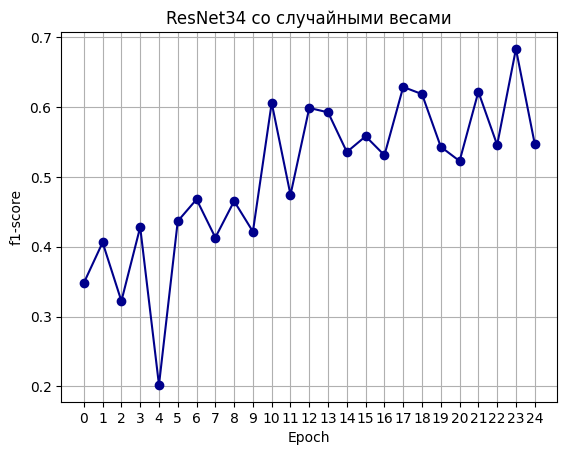

```python
resnet34_model_random = resnet34_random_weights(num_classes).to(device)

f1_validation_resnet34_random, f1_test_resnet34_random = experiment(resnet34_model_random)
plot_f1_score(f1_validation_resnet34_random, epochs, "ResNet34 со случайными весами")
```

```
Downloading: "https://download.pytorch.org/models/resnet34-b627a593.pth" to /root/.cache/torch/hub/checkpoints/resnet34-b627a593.pth
```

```
Epoch: 1/25
train loss = 1.071, train accuracy = 0.604, train time = 7.07
validation loss = 0.697, validation accuracy = 0.745, validation time = 1.86, f1-score = 0.665

Epoch: 2/25
train loss = 0.666, train accuracy = 0.763, train time = 7.38
validation loss = 0.490, validation accuracy = 0.826, validation time = 1.86, f1-score = 0.792

Epoch: 3/25
train loss = 0.503, train accuracy = 0.826, train time = 7.33
validation loss = 0.527, validation accuracy = 0.823, validation time = 1.90, f1-score = 0.792

Epoch: 4/25
train loss = 0.452, train accuracy = 0.839, train time = 6.61
validation loss = 0.445, validation accuracy = 0.823, validation time = 2.12, f1-score = 0.791

Epoch: 5/25
train loss = 0.437, train accuracy = 0.837, train time = 6.98
validation loss = 0.476, validation accuracy = 0.819, validation time = 1.88, f1-score = 0.783

Epoch: 6/25
train loss = 0.470, train accuracy = 0.826, train time = 7.53
validation loss = 0.426, validation accuracy = 0.844, validation time = 1.86, f1-score = 0.821

Epoch: 7/25
train loss = 0.397, train accuracy = 0.861, train time = 7.47
validation loss = 0.387, validation accuracy = 0.871, validation time = 1.90, f1-score = 0.849

Epoch: 8/25
train loss = 0.320, train accuracy = 0.883, train time = 6.83
validation loss = 0.406, validation accuracy = 0.877, validation time = 2.18, f1-score = 0.854

Epoch: 9/25
train loss = 0.306, train accuracy = 0.885, train time = 6.88
validation loss = 0.527, validation accuracy = 0.813, validation time = 1.85, f1-score = 0.783

Epoch: 10/25
train loss = 0.283, train accuracy = 0.901, train time = 7.26
validation loss = 0.393, validation accuracy = 0.861, validation time = 1.82, f1-score = 0.842

```

[output cut: 46 more lines]

```
validation loss = 0.420, validation accuracy = 0.864, validation time = 1.83, f1-score = 0.841

Epoch: 23/25
train loss = 0.139, train accuracy = 0.950, train time = 6.76
validation loss = 0.441, validation accuracy = 0.846, validation time = 2.25, f1-score = 0.834

Epoch: 24/25
train loss = 0.120, train accuracy = 0.962, train time = 6.59
validation loss = 0.426, validation accuracy = 0.855, validation time = 1.85, f1-score = 0.826

Epoch: 25/25
train loss = 0.117, train accuracy = 0.963, train time = 7.38
validation loss = 0.410, validation accuracy = 0.866, validation time = 1.89, f1-score = 0.832

Test f1-score:0.801
```

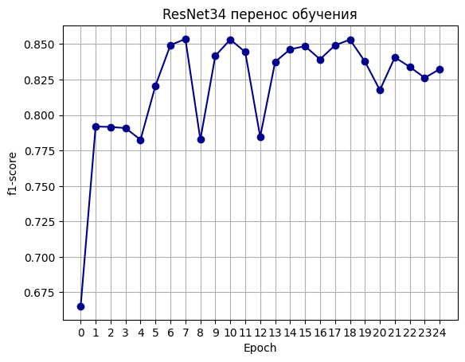

```python
resnet34_model_transform = resnet34_transfer(num_classes).to(device)

f1_validation_resnet34_transfer, f1_test_resnet34_transfer = experiment(resnet34_model_transform)
plot_f1_score(f1_validation_resnet34_transfer, epochs, "ResNet34 перенос обучения")
```

#### ResNet-50

```python
def resnet50_random_weights(num_classes):
    model = models.resnet50(weights=None)
    for param in model.parameters():
        param.requires_grad = True  # Все параметры обучаются

    # Заменяем последний полносвязный слой
    model.fc = nn.Linear(model.fc.in_features, num_classes)
    return model

def resnet50_transfer(num_classes):
    model = models.resnet50(weights=models.ResNet50_Weights.DEFAULT)
    for param in model.parameters():
        param.requires_grad = False

    model.fc = nn.Sequential(nn.Linear(2048, 512),
                             nn.ReLU(),
                             nn.Dropout(0.5),
                             nn.Linear(512, num_classes)
    )

    return model
```

Гиперпараметры обучения

```python
learning_rate = 0.005
epochs = 30
batch_size = 16
```

```python
train_loader = torch.utils.data.DataLoader(train_dataset, batch_size = batch_size, shuffle = True)
validation_loader = torch.utils.data.DataLoader(validation_dataset, batch_size = batch_size, shuffle = True)
test_loader = torch.utils.data.DataLoader(test_dataset, batch_size = batch_size, shuffle = False)
```

```
Epoch: 1/30
train loss = 2.149, train accuracy = 0.314, train time = 18.13
validation loss = 1.432, validation accuracy = 0.451, validation time = 2.34, f1-score = 0.335

Epoch: 2/30
train loss = 1.553, train accuracy = 0.411, train time = 18.08
validation loss = 1.513, validation accuracy = 0.420, validation time = 2.60, f1-score = 0.338

Epoch: 3/30
train loss = 1.458, train accuracy = 0.421, train time = 17.93
validation loss = 1.410, validation accuracy = 0.429, validation time = 2.44, f1-score = 0.319

Epoch: 4/30
train loss = 1.391, train accuracy = 0.461, train time = 17.94
validation loss = 1.404, validation accuracy = 0.451, validation time = 2.32, f1-score = 0.351

Epoch: 5/30
train loss = 1.355, train accuracy = 0.469, train time = 17.95
validation loss = 1.302, validation accuracy = 0.482, validation time = 2.32, f1-score = 0.358

Epoch: 6/30
train loss = 1.324, train accuracy = 0.482, train time = 18.00
validation loss = 1.273, validation accuracy = 0.474, validation time = 2.64, f1-score = 0.365

Epoch: 7/30
train loss = 1.312, train accuracy = 0.484, train time = 18.01
validation loss = 1.270, validation accuracy = 0.482, validation time = 2.40, f1-score = 0.379

Epoch: 8/30
train loss = 1.272, train accuracy = 0.506, train time = 17.98
validation loss = 1.159, validation accuracy = 0.555, validation time = 2.35, f1-score = 0.479

Epoch: 9/30
train loss = 1.268, train accuracy = 0.522, train time = 17.98
validation loss = 1.197, validation accuracy = 0.516, validation time = 2.86, f1-score = 0.426

Epoch: 10/30
train loss = 1.203, train accuracy = 0.535, train time = 17.98
validation loss = 1.264, validation accuracy = 0.489, validation time = 2.34, f1-score = 0.402

```

[output cut: 66 more lines]

```
validation loss = 0.892, validation accuracy = 0.705, validation time = 2.37, f1-score = 0.647

Epoch: 28/30
train loss = 0.721, train accuracy = 0.742, train time = 17.98
validation loss = 1.187, validation accuracy = 0.550, validation time = 2.33, f1-score = 0.462

Epoch: 29/30
train loss = 0.671, train accuracy = 0.744, train time = 18.01
validation loss = 0.917, validation accuracy = 0.671, validation time = 2.70, f1-score = 0.600

Epoch: 30/30
train loss = 0.660, train accuracy = 0.754, train time = 18.00
validation loss = 0.989, validation accuracy = 0.630, validation time = 2.40, f1-score = 0.571

Test f1-score:0.583
```

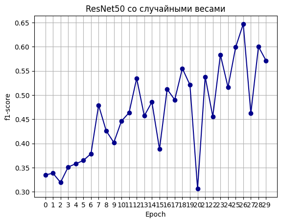

```python
resnet50_model_random = resnet50_random_weights(num_classes).to(device)

f1_validation_resnet50_random, f1_test_resnet50_random = experiment(resnet50_model_random)
plot_f1_score(f1_validation_resnet50_random, epochs, "ResNet50 со случайными весами")
```

```
Downloading: "https://download.pytorch.org/models/resnet50-11ad3fa6.pth" to /root/.cache/torch/hub/checkpoints/resnet50-11ad3fa6.pth
```

```
Epoch: 1/12
train loss = 0.837, train accuracy = 0.684, train time = 6.78
validation loss = 0.479, validation accuracy = 0.821, validation time = 2.64, f1-score = 0.788

Epoch: 2/12
train loss = 0.373, train accuracy = 0.865, train time = 7.01
validation loss = 0.340, validation accuracy = 0.863, validation time = 2.38, f1-score = 0.842

Epoch: 3/12
train loss = 0.236, train accuracy = 0.914, train time = 7.37
validation loss = 0.337, validation accuracy = 0.876, validation time = 2.39, f1-score = 0.838

Epoch: 4/12
train loss = 0.166, train accuracy = 0.941, train time = 7.38
validation loss = 0.290, validation accuracy = 0.881, validation time = 2.39, f1-score = 0.871

Epoch: 5/12
train loss = 0.151, train accuracy = 0.949, train time = 6.99
validation loss = 0.344, validation accuracy = 0.877, validation time = 2.63, f1-score = 0.878

Epoch: 6/12
train loss = 0.126, train accuracy = 0.956, train time = 6.73
validation loss = 0.389, validation accuracy = 0.882, validation time = 2.63, f1-score = 0.881

Epoch: 7/12
train loss = 0.088, train accuracy = 0.969, train time = 7.09
validation loss = 0.332, validation accuracy = 0.905, validation time = 2.41, f1-score = 0.881

Epoch: 8/12
train loss = 0.066, train accuracy = 0.982, train time = 7.43
validation loss = 0.314, validation accuracy = 0.895, validation time = 2.41, f1-score = 0.876

Epoch: 9/12
train loss = 0.059, train accuracy = 0.978, train time = 7.37
validation loss = 0.448, validation accuracy = 0.879, validation time = 2.41, f1-score = 0.864

Epoch: 10/12
train loss = 0.074, train accuracy = 0.979, train time = 7.09
validation loss = 0.409, validation accuracy = 0.876, validation time = 2.58, f1-score = 0.870

Epoch: 11/12
train loss = 0.064, train accuracy = 0.980, train time = 6.70
validation loss = 0.477, validation accuracy = 0.875, validation time = 2.69, f1-score = 0.855

Epoch: 12/12
train loss = 0.065, train accuracy = 0.981, train time = 6.93
validation loss = 0.365, validation accuracy = 0.910, validation time = 2.39, f1-score = 0.906

Test f1-score:0.841
```

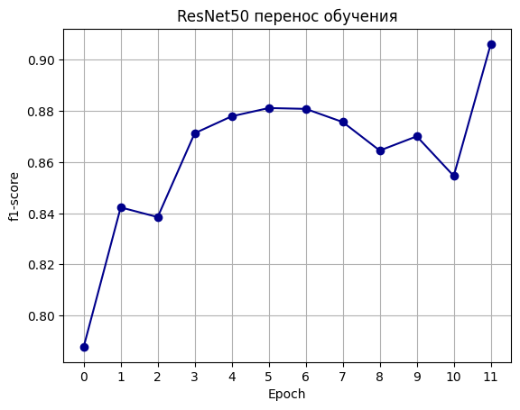

```python
epochs = 12
batch_size = 64

train_loader = torch.utils.data.DataLoader(train_dataset, batch_size = batch_size, shuffle = True)
validation_loader = torch.utils.data.DataLoader(validation_dataset, batch_size = batch_size, shuffle = True)
test_loader = torch.utils.data.DataLoader(test_dataset, batch_size = batch_size, shuffle = False)

resnet50_model_transform = resnet50_transfer(num_classes).to(device)

f1_validation_resnet50_transfer, f1_test_resnet50_transfer = experiment(resnet50_model_transform)
plot_f1_score(f1_validation_resnet50_transfer, epochs, "ResNet50 перенос обучения")
```

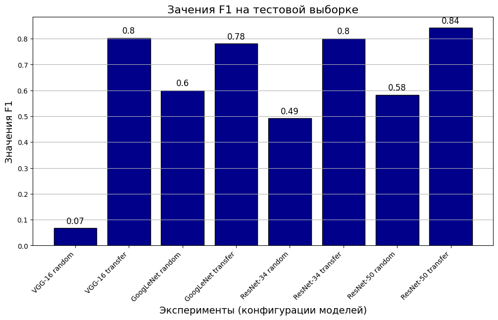

```python
name_models = [
    'VGG-16 random',
    'VGG-16 transfer',
    'GoogLeNet random',
    'GoogLeNet transfer',
    'ResNet-34 random',
    'ResNet-34 transfer',
    'ResNet-50 random',
    'ResNet-50 transfer'
]

f1_test = [
    f1_test_vgg16_random,
    f1_test_vgg16_transfer,
    f1_test_googlenet_random,
    f1_test_googlenet_transfer,
    f1_test_resnet34_random,
    f1_test_resnet34_transfer,
    f1_test_resnet50_random,
    f1_test_resnet50_transfer
]

plt.figure(figsize=(12, 6))
bars = plt.bar(name_models, f1_test, color = 'darkblue', edgecolor = 'black')
plt.xlabel("Эксперименты (конфигурации моделей)", fontsize = 14)
plt.ylabel("Значения F1", fontsize = 14)

for bar in bars:
    yval = bar.get_height()
    plt.text(bar.get_x() + bar.get_width() / 2, yval + 0.01, round(yval, 2), ha='center', va='bottom', fontsize=12)

plt.title("Зачения F1 на тестовой выборке", fontsize=16)
plt.xticks(rotation = 45, ha = 'right')
plt.grid(axis='y')
plt.show()
```